# Brauchen wir ‘fortgeschrittenere’ Statistik in der Geographie?

Ina Krapp

ina.krapp@freenet.de

01.10.2026

## Was ist Statistik?

- Deskriptive Statistik: Zusammenfassung, Visualisierung
- Das Versprechen: Aussagen über X, Y und ihre Gemeinsamkeiten und Unterschiede
- Inferenzstatistik: Modellierung von Zusammenhängen, Vorhersage
- Das Versprechen: Anhand von Zahlen beweisen, dass $X \rightarrow Y$gilt

## Das Paradox der Regression

- Lineare Regression modelliert den Zusammenhang zwischen Variablen X und Y
- Voraussetzung: Es muss ein linearer Zusammenhang der Form $X \rightarrow Y$ bestehen
- Heißt das, man kann sie nur anwenden, wenn man den Zusammenhang vorher schon kennt? Braucht man sie dann noch?
- Regression trifft auch Aussagen über Stärke und Richtung des Zusammenhanges
- Aber: Sie erfordert sehr viele Annahmen

## Das Annahmenproblem

- Je ‘fortgeschrittener’ eine statistische Methode ist, desto mehr Annahmen braucht sie in der Regel:
- Median, Mittelwert und Standardabweichung: (Fast) keine Annahmen
- Lineare Regression: Erfordert Annahmen über Richtung ($X \rightarrow Y$), lineare Form des Zusammenhanges und Unabhängigkeit von weiteren Einflüssen
- Viele dieser Annahmen lassen sich selten oder gar nicht testen, die Unabhängigkeit von weiteren Einflüssen ist fast nie erfüllt

## Wie häufig ist die Normalverteilung?

Für das Berechnen von p-Werten wurde oft davon ausgegangen, dass Werte normalverteilt sind. Aber nicht normalverteilt sind bspw.

## Wie häufig ist die Normalverteilung?

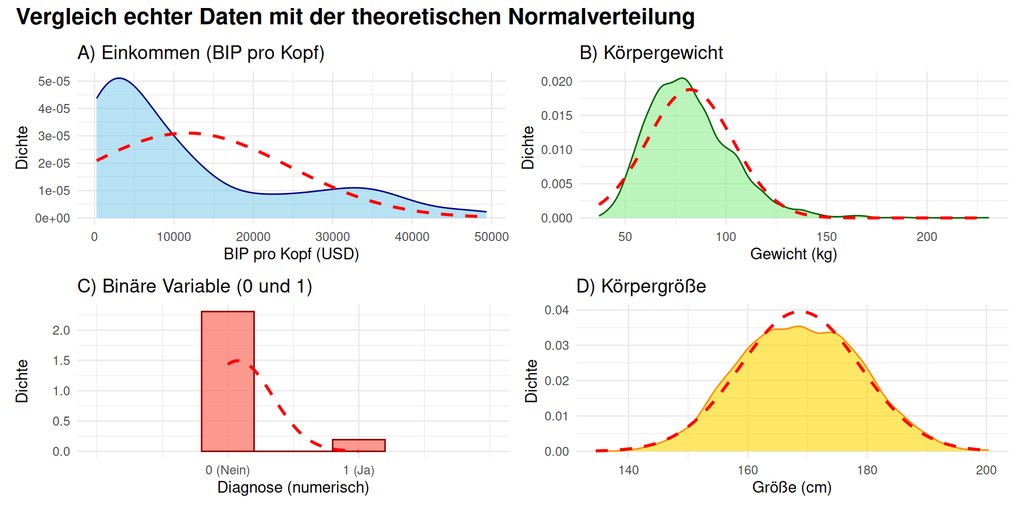

## Das Problem mit der Autokorrelation

- Die Lösung: Robuste Standardfehler
- Das nächste Problem: Diese erfassen keine räumliche oder zeitliche Autokorrelation…
- Regressionen räumlicher Daten in einfachen linearen Regressionen sind fast immer signifikant - selbst wenn die Variablen zufällig generiert sind!

## Nähere Orte haben mehr miteinander gemeinsam

Dieser Effekt tritt immer dann auf, wenn näher beieinander liegende Orte sich ähneln.

Ein Beispiel lässt sich folgendermaßen simulieren

1. Ich generiere 5 zufällige Zentren
2. Ich gebe 500 zufällig im Raum verteilten Punkten Werte, die von der Entfernung zu den Zentren abhängen

## Die Simulation

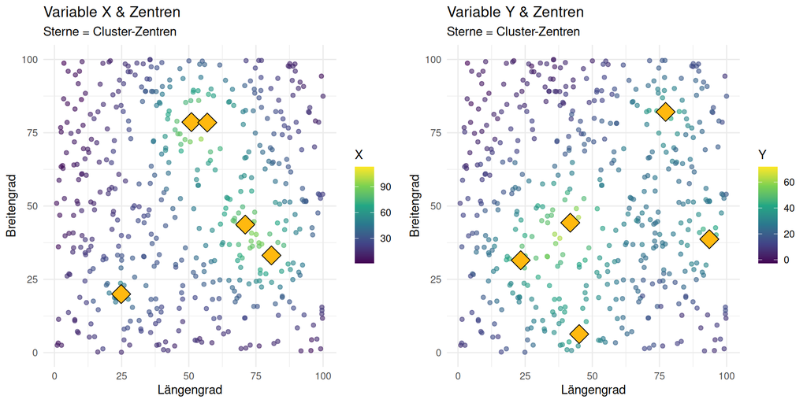

## Nähere Orte haben mehr miteinander gemeinsam

- Da es ein Zufallsprozess ist, sind X und Y unabhängig voneinander
- Dennoch ist der statistische Zusammenhang zwischen ihnen in einem linearen Modell fast immer signifkant
- Der Koeffizient kann positiv oder negativ sein

## Die künstliche Signifikanz

```
SIMULATION: Räumliche Autokorrelation vs. Unabhängigkeit
```

```
Nominale Stichprobe (n): 500 | Effektive Cluster (k): 5
```

```
Koeffizient (Richtung des Zusammenhangs): 0.1218
```

```
Modell               Koeff.       Std.Error    t-Stat       p-Wert
```

```
OLS (falsch)         0.1218       0.0246       4.9524       0.0000
```

```
Korrigiert           0.1218       0.2460       0.4952       0.6464
```

```
ERGEBNIS: OLS meldet fälschlicherweise Signifikanz (Typ-I-Fehler)!
```

## Das wirkliche Problem: Die Stichprobengröße

- In linearer Regression wird Signifikanz anhand der Zahl der voneinander unabhängigen Beobachtungen berechnet
- Im Beispiel wurde sie zunächst an 500 Beobachtungen berechnet - unabhängig voneinander waren aber nur 5
- Gerade im geographischem Kontext ist fraglich, ob es voneinander unabhängige Beobachtungen gibt

## Länder als Kontrollvariablen?

- Räumliche oder zeitliche Einheiten (Länder, Jahre) als erklärende Variablen sind oft sehr gut darin, einen hohen Prozentsatz der Daten zu ‘erklären’
- Kausale Zusammenhänge werden durch sie aber eher verborgen als gefunden
- Sie sind leicht für politische Zwecke manipulierbar, da Räume beliebig zugeschnitten werden können
- Zum Finden der ‘richtigen’ Räume bräuchte man Einsicht in den realen Datengenerierungsprozess…und hätte man diese, bräuchte man die Statistik nicht mehr…

## Länder als Kontrollvariablen?

[figure not shown]

## Länder als Kontrollvariablen?

```
SIMULATION: Räumliche Autokorrelation (64 Boxen)
```

```
Nominale Stichprobe (n): 500 | Effektive Boxen (k): 64
```

```
Koeffizient (Richtung des Zusammenhangs): ~0.1218 (naiv) vs ~0.1703 (Boxen)
```

```
Modell               Koeff.       Std.Error    t-Stat       p-Wert
```

```
OLS (n=500)          0.1218       0.0246       4.9524       0.0000
```

```
Boxen (n=64)         0.1703       0.0749       2.2721       0.0266
```

```
ERGEBNIS: Beide Modelle sehen auf dem 5%-Niveau einen Zusammenhang.
```

## Ausblick:

- Da immer mehr geographisch kleinräumige Daten auch in anderen Wissenschaften (VWL, Soziologie, Politikwissenschaften) verwendet werden, wird das Problem auch dort präsenter
- Gleichzeitig sind nicht-räumliche Daten (in denen räumliche Zusammenhänge ‘versteckt’ sind) auch keine Lösung
- Auch andere (nichtlineare) Modelle haben nicht-widerlegbare Annahmen

## Was kann man da machen?

- Deskriptive Statistik sollte nicht zugunsten ‘fortgeschrittener’ Methoden vernachlässigt werden
- Interviews und andere Formen qualitativer Forschung sind eine unverzichtbare Ergänzung zu ‘reiner’ Statistik
- Sollten Modelle Erkenntnissen aus der deskriptiven Statistik oder qualitativer Forschung widersprechen, Modellannahmen kritisch hinterfragen
- “Alle Modelle sind falsch, aber manche sind nützlich”

## Quellen

- **Conley, T., & Kelly, M.** (2025). The standard errors of persistence. *Journal of International Economics*, *153*, 104027. [DOI](https://doi.org/10.1016/j.jinteco.2024.104027)
- **R Core Team.** (2026). *R: A Language and Environment for Statistical Computing*. R Foundation for Statistical Computing. [DOI](https://doi.org/10.32614/R.manuals)
- **Wickham, H., et al.** (2019). Welcome to the tidyverse. *Journal of Open Source Software*, *4*(43), 1686. [DOI](https://doi.org/10.21105/joss.01686)
- [All models are wrong](https://en.wikipedia.org/wiki/All_models_are_wrong)
- **Auguie, B.** (2026). *gridExtra: Miscellaneous Functions for “Grid” Graphics* (Version 2.3.1) [R package]. [DOI](https://doi.org/10.32614/CRAN.package.gridExtra)
- **Bryan, J.** (2025). *gapminder: Data from Gapminder* (Version 1.0.1) [R package]. [DOI](https://doi.org/10.32614/CRAN.package.gapminder)
- **Pedersen, T.** (2025). *patchwork: The Composer of Plots* (Version 1.3.2) [R package]. [DOI](https://doi.org/10.32614/CRAN.package.patchwork)
- **Pruim, R.** (2026). *NHANES: Data from the US National Health and Nutrition Examination Study* (Version 2.1.4) [R package]. [DOI](https://doi.org/10.32614/CRAN.package.NHANES)